# SAEIV - Application web PHP

## Présentation

Les transports en commun se modernisent. Régis par l’arrêté du 3 Mai 2007, les bus mis en circulation doivent disposer d’un système d’informations voyageurs (SIV) sonores et visuelles.

**Il s’agit de réaliser une application web capable d’améliorer l’information donnée aux usagers.** Elle doit permettre de visualiser les horaires pour une ligne sélectionné par l’utilisateur.

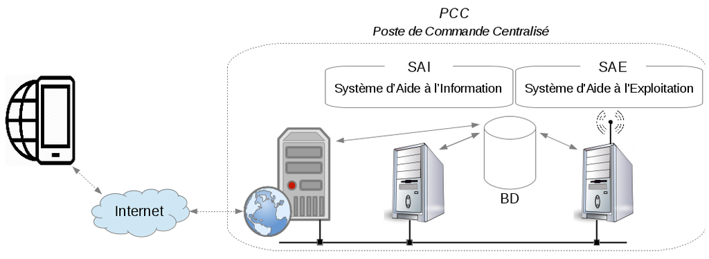

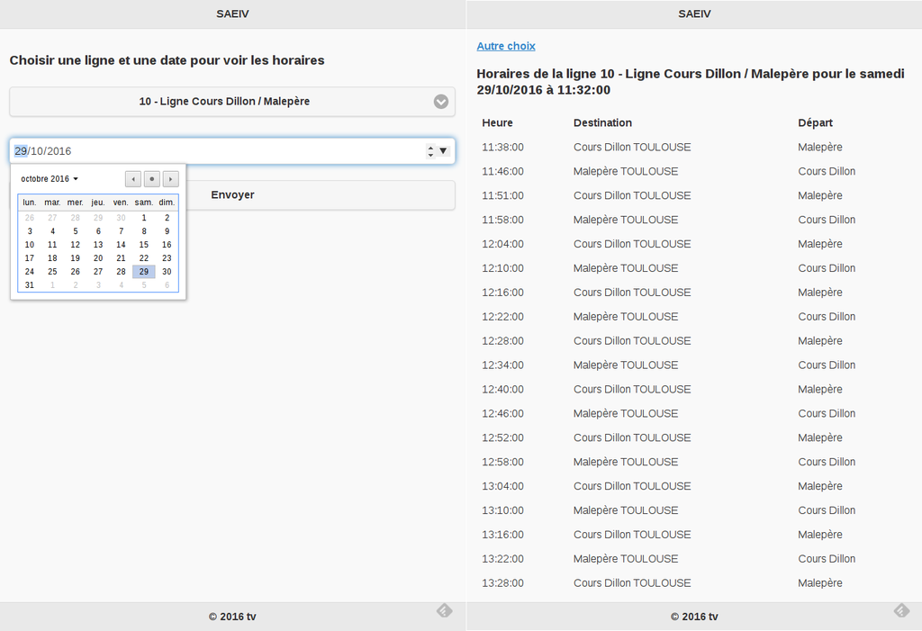

Le référentiel est un ensemble de données descriptives de l’exploitation du réseau (référentiel SAE). Ces données concernent :

- la description de la topologie du réseau : lignes, arrêts, chaînages des tronçons, etc.
- la description des horaires : calendriers, services matériels etc.
- la description des ressources : conducteurs, véhicules etc.

Ces données sont mémorisées dans la BD (base de données) du PCC, et mises à disposition des différents sous-systèmes en fonction de leurs besoins.

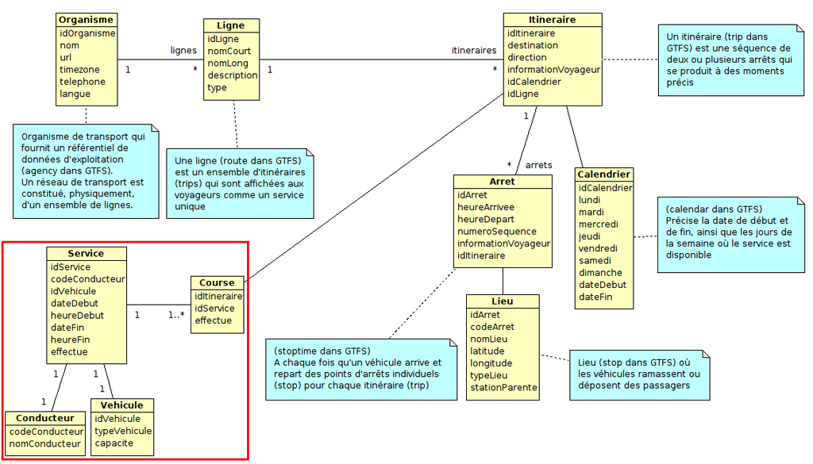

Voir l’activité base de données SAE.

## Contraintes d’environnement

| Ressource | Version |
| --- | --- |
| OS | GNU Linux (Ubuntu 12.04.5 LTS) |
| EDI | Geany |
| SERVEUR | Apache |
| PHP | PHP 5.x |
| SGBDR | MySQL |

## Ressources

- [Supports de cours PHP](http://tvaira.free.fr/web/)
- [Manuel PHP](https://php.net/manual/fr/)
- [jQuery Mobile](http://jquerymobile.com)
- [jQuery Mobile Docs & Demos](http://demos.jquerymobile.com)
- [Apprendre la programmation mobile pour les téléphones Android](http://olegoaer.developpez.com/cours/mobile/)
- [Démarrer par l’exemple I](http://www.alsacreations.com/tuto/lire/1459-jquery-mobile-par-lexemple-la-kiwiparty.html)
- [Démarrer par l’exemple II](http://www.alsacreations.com/tuto/lire/1486-jquery-mobile-par-lexemple-dmarrer.html)

## PHP

PHP est un langage de programmation de scripts côté serveur permettant de produire des pages web dynamiques.

Les scripts PHP :

- sont de simples fichiers “texte” (extension conseillée `.php`) à créer avec un éditeur de texte
- contiennent du code PHP mélangeables à du code HTML
- sont exécutés côté serveur par un “interpréteur” php (*parser* php)

Généralement, PHP sert à **produire des pages web dynamiques** et donc à récupérer et traiter des informations issues d’une base de données, d’un système de fichiers (contenu de fichiers et de l’arborescence) ou plus simplement des données envoyées par le navigateur (url, formulaire, …).

Le code PHP doit être inséré entre des balises `<?php` et `?>`. Le script doit porter une extension reconnue par le serveur (extension conseillée `.php`).

Un simple script PHP :

```php
<HTML>
   <HEAD>
      <!-- Un titre -->
      <TITLE>Exemple 1</TITLE>
   </HEAD>
   <BODY>
    <?php
    // forme la plus simple, recommandée
    echo '<P>Hello World!</P>';
    ?>
   </BODY>
</HTML>
```

Pour réaliser un développement PHP, il vous faut la chaîne complète client/serveur HTTP. Plusieurs solutions s’offrent à vous :

- le serveur est présent en local sur votre machine de développement (*localhost*). Le plus souvent sous Linux, la racine des documents du serveur se trouvent en `/var/www/` . Et l’accès par le navigateur se fait à l’adresse : http://localhost/ ou http://votre-adresse-ip/
- le serveur est présent sur l’intranet de votre structure de développement (entreprise, école, université, domicile, …). Le serveur de la section est configuré pour un accès pour chaque compte. La racine se trouve dans votre répertoire personnel `$HOME/public_html/` et l’accès client se fait par exemple à l’adresse : http://192.168.52.85/~$LOGIN/
- le serveur est présent sur l’Internet, le plus souvent chez un hébergeur. Dans ce cas, il faut transférer les documents de votre poste de développement vers le serveur Internet (le plus souvent en FTP).

Remarque : LAMP est un acronyme désignant un ensemble de logiciels libres permettant de construire des serveurs de sites web. L’acronyme original se réfère aux logiciels suivants : Linux (l’OS GNU/Linux), Apache (le serveur Web), MySQL (le serveur de base de données) et PHP (le langage de script). Il existe aussi une architecture WAMP utilisée pour développer des sites web sur une machine Windows .

Le code PHP est composé par des appels à des fonctions, dans le but d’affecter des valeurs à des variables, le tout encadré dans des conditions, des boucles.

- Les instructions sont séparées par des `;`
- les variables sont toujours préfixées par un `$`
- Les blocs d’instructions sont délimités par les caractères `{` et `}`

PHP supporte les commentaires de type C, C++ et Shell Unix (aussi appelé style Perl) : `//`, `/* */` et `#`.

Un exemple de script PHP :

```php
<?php
// URL : http://localhost/helloworld-2.php?lang=fr
$lang = strtolower($_GET['lang']); // appel de la fonction strtolower()

if ($lang === 'fr') # test du type ET de la valeur
{
    $message = 'Bonjour le monde !'; /* une chaîne de caractères protégée */
}
elseif ($lang == 'en') # test de la valeur seulement
{
    $message =  "Hello"." World!"; // une concaténation de chaînes de caractères avec le .
}
else
{
    $message =  "Je ne vois pas quelle est votre langue $lang !"; // une chaîne de caractères non protégée
}

echo "<b>".$message."</b><br>"; // affiche (en gras) le contenu de la variable message
?>
```

Manuel PHP : https://php.net/manual/fr/

## JQuery Mobile

JQuery Mobile est un *framework* d’interface optimisé pour les appareils mobiles tactiles. Son objectif est de permettre de rapidement développer des applications mobiles ou des applications web monopage en réponse à la grande diversité des Smartphones et tablettes sur le marché. Il est développé par l’équipe du projet JQuery. Il s’appuie sur l’utilisation des technologies du web : **HTML5, CSS3, DOM, Javascript, Ajax**.

De manière générale, on développe des documents HTML5 et jQuery Mobile ajoute des éléments et des attributs de style adaptées aux terminaux mobiles.

Les bibliothèques de jQuery Mobile sont requises et on peut :

- soit stockées en local sur votre serveur
- soit directement sur le serveur public jQuery.com

On effectue l’importation dans l’en-tête du document :

- de la feuille de style spécifique mobile (`.css`)
- de la bibliothèque JavaScript jQuery (`.js`)
- de la bibliothèque JavaScript jQuery Mobile (`.js`)

```html
<!DOCTYPE html>
<html lang="fr">
    <head>
        <title>Un titre !</title>
        <meta charset="utf-8">
        <meta name="viewport" content="width=device-width, initial-scale=1">
        <!-- les bibliothèques pour jQuery Mobile -->
        <!-- <link rel="stylesheet" href="http://code.jquery.com/mobile/1.0.1/jquery.mobile-1.0.1.min.css" /> -->
        <!-- <script src="http://code.jquery.com/jquery-1.6.4.min.js"></script> -->
        <!-- <script src="http://code.jquery.com/mobile/1.0.1/jquery.mobile-1.0.1.min.js"></script> -->
        <link rel="stylesheet" href="http://code.jquery.com/mobile/1.4.5/jquery.mobile-1.4.5.min.css" />
        <script src="http://code.jquery.com/jquery-1.12.4.min.js"></script>
        <script src="http://code.jquery.com/mobile/1.4.5/jquery.mobile-1.4.5.min.js"></script>
    </head>
    <body>
    </body>
</html>
```

Vous pouvez structurer l’application web suivant deux approches :

- monopage : un document par page et on utilise des liens et l’*id* de la page (href=“page2.html#page2”)
- multipages : un document contient *n* pages et on utilise les ancres de la balise `a` à partir de l’*id* des pages (href=“#page2”)

Les pages sont créés à partir de la balise `section` dans le document. On exploite ensuite les [attributs](http://demos.jquerymobile.com/1.2.0/docs/api/data-attributes.html) fournis par JQuery Mobile :

- `data-role` : précise la nature du bloc (`page`|`header`|`content`|`footer`)
- `data-position` : spécifie où l’élément doit être positionné (`top`|`bottom`|`right`|`left`)
- `data-inset` : spécifie si l’élément doit être contenu dans les marges ou à l’extérieur de celles-ci (`true`|`false`)
- `data-transition` : spécifie quelle transition utiliser lors du chargement de nouvelles pages (`slide`|`slideup`|`slidedown`|`pop`|`flip`|`fade`)
- `data-theme` : spécifie le thème graphique à utiliser pour les éléments d’un conteneur (`a`|`b`|`c`|`d`|`e`)
- …

Une simple page :

```html
<!DOCTYPE html>
<html lang="fr">
    <head>
        <title>Un site pour Mobile</title>
        <meta charset="utf-8">
        <meta name="viewport" content="width=device-width, initial-scale=1">
        <link rel="stylesheet" href="http://code.jquery.com/mobile/1.0.1/jquery.mobile-1.0.1.min.css" />
        <script src="http://code.jquery.com/jquery-1.6.4.min.js"></script>
        <script src="http://code.jquery.com/mobile/1.0.1/jquery.mobile-1.0.1.min.js"></script>
        <style type="text/css">
        .center { text-align:center; }
        .margesinternes { margin:0.5em; }
        </style>
    </head>
    <body>
        <!-- une page -->
        <section id="page1" data-role="page" data-add-back-btn="true">
            <!-- en-tête -->
            <header data-role="header"><h1>Titre du site</h1></header>
            <h2 class="center">
                Un titre niveau 2
            </h2>
            <h3 class="center">
                Un titre niveau 3
            </h3>
            <p class="center">
                <!-- un logo -->
                <img src="logo-montagne.jpg" alt="Un logo !" width="160" height="124" />
            </p>

            <!-- une vue dépliante -->
            <div data-role="collapsible" data-content-theme="a">
                <h3>La station</h3>
                <p>...</p>
                <img src="pistes.png" alt="" width="" height=""/>
            </div>

            <div data-role="collapsible" data-content-theme="b">
                <h3>Ski de fond</h3>
                <p>Le domaine nordique est un paradis pour les fondeurs ...</p>
            </div>

            <div data-role="collapsible" data-content-theme="c">
                <h3>Ski alpin</h3>
                <p>La station vous offre une garantie d’enneigement ... </p>
                <!-- une grille à 2 colonnes -->
                <div class="ui-grid-a ui-responsive">
                    <div class="ui-block-a">
                        <div class="margesinternes">
                            <h3>Tarifs</h3>
                            <p>...</p>
                        </div>
                    </div>
                    <div class="ui-block-b">
                        <div class="margesinternes">
                            <h3>Les pistes</h3>
                            <img src="skieur.png" alt="" width="" height=""/>
                        </div>
                    </div>
                </div>
            </div>

            <div data-role="collapsible" data-content-theme="d">
                <h3>Snowkite</h3>
                <p>Le snowkite est à la portée de tous ceux qui recherchent de nouvelles sensations sur la neige en skis ou en surf ...</p>
                <img src="snow.png" alt="" width="" height=""/>
            </div>

            <!-- une vue en liste -->
            <ul data-role="listview" data-inset="true">
                <li>
                  <a href="#page2" data-transition="slide">
                  <h3>En savoir plus ...</h3>
                  <p><img class="margesimg" src="station.png" alt="" /></p>
                  </a>
                </li>
            </ul>
            <p></p>
            <!-- un pied de page -->
            <footer data-role="footer"><h1>©&nbsp;2016&nbsp;</h1></footer>
        </section>

        <!-- une deuxième page -->
        <section id="page2" data-role="page">
            <header data-role="header"><h1>Titre du site</h1></header>
            <h2 class="center">
                Un titre niveau 2
            </h2>
            <h3 class="center">
                Un titre niveau 3
            </h3>
            <p class="center">
                <!-- un logo -->
                <img src="logo-montagne.jpg" alt="Un logo !" width="160" height="124" />
            </p>

            <div class="content" data-role="content">
                <p class="center">Contact : 04.04.04.04.04</p>
                <p class="center">Horaires d'ouverture : <br/>
                du 1er Decembre au 31 Mars,<br/>
                de 9h à 12h et de 13h30 à 17h30.</p>
            </div>

            <!-- des boutons -->
            <div class="center" data-role="controlgroup" data-type="horizontal" data-mini="true">
                <a href="#page1" data-role="button" data-icon="back" data-iconpos="left">Retour</a>
                <a href="mailto:info%40neige.com" data-role="button" data-icon="forward" data-iconpos="right" target="_blank">info(at)neige.com</a>
            </div>
            <footer data-role="footer" data-position="fixed"><h1>©&nbsp;2016&nbsp;</h1></footer>
        </section>

    </body>
</html>
```

On peut utiliser le navigateur Firefox ou l’extension [Ripple Emulator](https://chrome.google.com/webstore/detail/ripple-emulator-beta/) pour Chrome par exemple pour tester ou directement un *smartphone*.

[figure not shown]

## Travail demandé

1. Vérifier la présence du serveur web Apache.

```
// Présence des paquets Apache et de son module PHP
$ dpkg -l | grep -i apache

// Présence des paquets PHP (au moins php5-common et php5-mysql)
$ dpkg -l | grep -i php

// Le serveur web Apache est-il démarré ?
$ sudo service apache2 status
```

Normalement, le serveur est déjà installé sinon il faudra installer les paquets suivants :

```
$ sudo apt-get install apache2 apache2-bin apache2-data apache2-utils libapache2-mod-php5 php5-common php5-mysql
```

2. Créer l’application demandée.

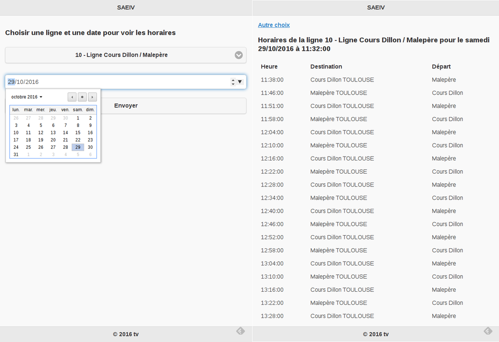

1. Créer un script `index.php` dans `/var/www/saeiv/` et compléter le formulaire :

```html
<!DOCTYPE html>
<html lang="fr">
    <head>
        <title>SAEIV-PHP</title>
        <meta charset="utf-8">
        <meta name="viewport" content="width=device-width, initial-scale=1">
        <!-- les bibliothèques pour jQuery Mobile -->
        <link rel="stylesheet" href="http://code.jquery.com/mobile/1.4.5/jquery.mobile-1.4.5.min.css" />
        <script src="http://code.jquery.com/jquery-1.12.4.min.js"></script>
        <script src="http://code.jquery.com/mobile/1.4.5/jquery.mobile-1.4.5.min.js"></script>
    </head>
    <body>
        <!-- une page -->
        <section id="page1" data-role="page" data-add-back-btn="true">
            <!-- une en-tête -->
            <header data-role="header">
                <h1>SAEIV</h1>
            </header>
            <!-- un contenu -->
            <div data-role="main" class="ui-content">
                <!-- cf. http://demos.jquerymobile.com/1.4.3/forms/ -->
                <form method="post" action="index.php">
                    <!-- TODO -->
                </form>
            </div>
            <!-- un pied de page -->
            <footer data-role="footer" data-position="fixed">
                <h1>©&nbsp;2016&nbsp;La Salle Avignon</h1>
            </footer>
        </section>
    </body>
</html>
```

Lien : http://demos.jquerymobile.com/1.4.3/forms/

2. Compléter le script `index.php` afin de finaliser le formulaire à partir des données contenues dans la table `ligne` de la base de données `sae`.

Exemple de script qui exécute une requête SELECT :

[figure not shown]

```php
<!DOCTYPE html>
<html lang="fr">
    <head>
        <title>SAEIV-PHP</title>
        <meta charset="utf-8">
        <meta name="viewport" content="width=device-width, initial-scale=1">
        <!-- les bibliothèques pour jQuery Mobile -->
        <link rel="stylesheet" href="http://code.jquery.com/mobile/1.4.5/jquery.mobile-1.4.5.min.css" />
        <script src="http://code.jquery.com/jquery-1.12.4.min.js"></script>
        <script src="http://code.jquery.com/mobile/1.4.5/jquery.mobile-1.4.5.min.js"></script>
    </head>
    <body>
        <!-- une page -->
        <section id="page1" data-role="page" data-add-back-btn="true">
            <!-- en-tête -->
            <header data-role="header">
                <h1>SAEIV</h1>
            </header>

            <div data-role="main" class="ui-content">
                <?php
                $mysqli = new mysqli("localhost", "root", "password", "sae");

                if ($mysqli->connect_error)
                {
                    die('Echec de connexion au serveur de base de données : ' . $mysqli->connect_error . '(' . $mysqli->connect_errno . ') ');
                }

                if ($result = $mysqli->query("SELECT idLigne, nomLong, description FROM ligne ORDER BY ligne.nomLong ASC"))
                {
                   printf("La requête a retourné %d enregistrement(s).<br /><br />\n", $result->num_rows);
                   while($row = $result->fetch_array())
                   {
                      $idLigne = $row["idLigne"];
                      $nomLong = utf8_encode($row["nomLong"]);
                      $description = utf8_encode($row["description"]);
                      echo "$idLigne -> Ligne $nomLong - $description<br />";
                      echo "<pre>"; var_dump($row); echo "</pre>";
                   }

                   /* Libération des résultats */
                   $result->free();
                }

                $mysqli->close();
                ?>
            </div>

            <!-- un pied de page -->
            <footer data-role="footer" data-position="fixed">
                <h1>©&nbsp;2016&nbsp;tv</h1>
            </footer>
        </section>
    </body>
</html>
```

3. Compléter le script `index.php` afin de traiter les données reçues du formulaire. Ici, les données sont reçues côté serveur dans la variable superglobale `$_POST`.

```php
<!DOCTYPE html>
<html lang="fr">
    <head>
        <title>SAEIV-PHP</title>
        <meta charset="utf-8">
        <meta name="viewport" content="width=device-width, initial-scale=1">
        <!-- les bibliothèques pour jQuery Mobile -->
        <link rel="stylesheet" href="http://code.jquery.com/mobile/1.4.5/jquery.mobile-1.4.5.min.css" />
        <script src="http://code.jquery.com/jquery-1.12.4.min.js"></script>
        <script src="http://code.jquery.com/mobile/1.4.5/jquery.mobile-1.4.5.min.js"></script>
    </head>
    <body>
        <!-- une page -->
        <section id="page1" data-role="page" data-add-back-btn="true">
            <!-- en-tête -->
            <header data-role="header">
                <h1>SAEIV</h1>
            </header>

            <div data-role="main" class="ui-content">

                <?php
                // Affihage de débuggage de la variable superglobale $_POST
                echo "<pre>"; var_dump($_POST); echo "</pre>";

                // Pas de ligne sélectionnée (ou vide ) ?
                if(!IsSet($_POST["idligne"]) || Empty($_POST["idligne"]))
                {
                    // Récuperer les lignes à partir de la base de données
                    // ...

                    $choix = "1";
                }
                else
                {
                    // Récuperer les horaires pour la $_POST["idligne"] ligne choisie
                    // ...

                    $retour = "<a href=\"".$_SERVER['PHP_SELF']."\" data-ajax=\"false\">Retour</a>";

                    $choix = "2";
                }
                ?>

                <?php
                if($choix == "1")
                {
                ?>
                    <!-- afficher le formulaire -->
                    <form method="post" action="index.php">
                        <!-- Exemple pour le test -->
                        <input type="text" name="idligne" id="idligne">
                        <input type="submit" value="Envoyer" />
                    </form>
                <?php
                }
                elseif($choix == "2")
                {
                    echo $retour;
                ?>
                    <!-- afficher les horaires dans une table -->
                <?php
                }
                else
                {
                    echo "Erreur !<br>";
                }
                ?>

            </div>

            <!-- un pied de page -->
            <footer data-role="footer" data-position="fixed">
                <h1>©&nbsp;2016&nbsp;tv</h1>
            </footer>
        </section>
    </body>
</html>
```

4. Compléter le script `index.php` afin d’afficher les horaires dans une `table`.

Exemple d’affichage de données dans une table :

```html
<table data-role="table" class="ui-responsive">
    <thead>
        <tr>
            <th>Heure</th>
            <th>Destination</th>
            <th>Départ</th>
        </tr>
    </thead>
    <tbody>
        <tr>
            <td>13:52:00</td>
            <td>Cours Dillon TOULOUSE</td>
            <td>Malepère</td>
        </tr>
        <tr>
            <td>13:58:00</td>
            <td>Malepère TOULOUSE</td>
            <td>Cours Dillon</td>
        </tr>
        <!-- etc ... -->
    </tbody>
</table>
```

Lien : http://www.w3schools.com/jquerymobile/jquerymobile_tables.asp

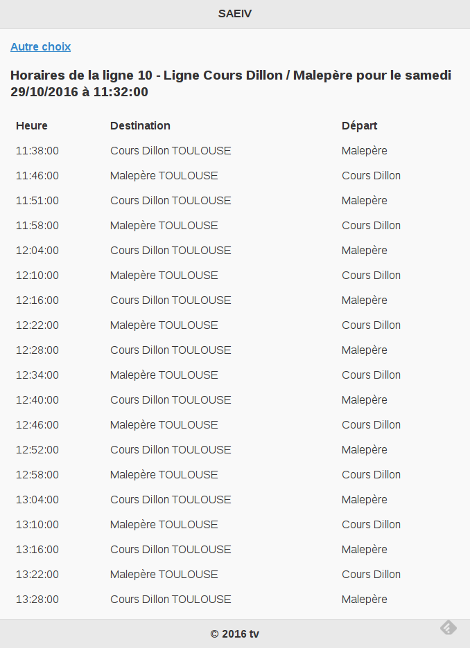

5. Bonus : Vous pouvez maintenant ajouter l’affichage des horaires des arrêts pour un itinéraire. Pour cela, il faudra cliquer sur des liens :

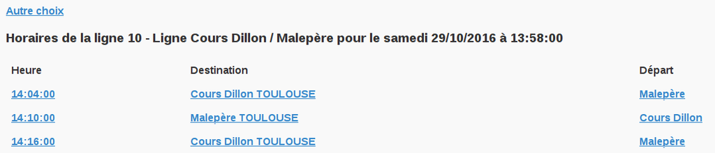

Retour au sommaire